# D212 Data Mining 2

## Performance Assessment 1

### A1: Research Question

Can meaningful clusters of customers be created using K-means to provide insights into customer behavior?

### A2: Goal of Analysis

The purpose of this analysis is to see if meaninful clusters of customers can be created from our data set. The goal is to see if we can find clusters that can be analyzed in such a way that they could provide insight into how better retain or market to certain customers. For example, what separates a customer who stays with the company a long time versus a customer who stays with the company for a short period of time.

### B1: Explanation of Clustering Technique

K-means clustering works by taking the given data and sorting it into a predefined number of clusters (k). It achieves this by first randomly selecting center points or centroids for each cluster and assigning every data point to the centroid closest to it. The centroids are then recalculated using the mean of the data points assigned to the cluster. The data points are then sorted again using the new centroids and the centroids are then recalculated until the centroids no longer change significantly or a specified number of iterations has executed. This process minimizes the sum of the squares of the distance between the individual points and their centroid. The expected result is a number of clusters with each cluster representing a group of similar points (Sharma, 2024). In the case of this analysis, each cluster should represent a group of similar customers.

### B2: Assumptions of Clustering Technique

One of the assumptions that K-means makes is that the clusters are spherical. Since it assigning data points based on distance from a centroid, the algorithm naturally creates spherically shaped clusters.

### B3: Packages for Analysis

```python
import pandas as pd
import numpy as np
import seaborn as sns
from sklearn.preprocessing import StandardScaler
from sklearn.cluster import KMeans
from sklearn.metrics import silhouette_score

import warnings
warnings.filterwarnings('ignore')
```

#### Pandas

The pandas packages is used for creating and manipulating data frames.

#### Numpy

The numpy package is used for creating and performing mathmatical operations with arrays.

#### Seaborn

Seaborn is used for its simple and easy to use plotting function. It is designed to work well with Pandas data frames.

#### StandardScaler from sklearn

This method is used to scale the data for analysis.

#### KMeans from sklearn

The KMeans function from sklearn is used to create the clustering model.

#### silhouette_score from sklearn

The silhouette_score is used to evaluate the quality of the clustering.

#### Warnings

This package is used to hide any future warning or other messages in Jupytar notebooks.

### C1: Preprocesssing Goals

The primary preprocessing goal for this analysis is to scale the data. K-means clustering uses the distance between points to create clusters and having variables on different scales will produce results that is not usable. To scale our data we will use StandardScaler from sklearn. This scales the data so that all the variables have a mean of zero and a standard deviation of 1.

### C2: Variables

##### Age: Continuous

Age of customer.

##### Income: Continuous

Annual income of customer.

##### Children: Continuous

Number of children in customer's household.

##### Monthly Charge: Continuous

The customer's monthly bill.

##### Tenure: Continuous

Customer's time with the company in months.

### C3: Data Preparation Steps

```python
# read in csv file
df = pd.read_csv('churn_clean.csv', na_values="NA", keep_default_na=False)
df.columns = df.columns.str.lower()

# create copy for analysis
churn_df = df.copy()
```

The first step of the data preparation process is to check for null values in the data.

```python
# check for null values
churn_df.info()
```

```
<class 'pandas.core.frame.DataFrame'>
RangeIndex: 10000 entries, 0 to 9999
Data columns (total 50 columns):
 #   Column                Non-Null Count  Dtype
---  ------                --------------  -----
 0   caseorder             10000 non-null  int64
 1   customer_id           10000 non-null  object
 2   interaction           10000 non-null  object
 3   uid                   10000 non-null  object
 4   city                  10000 non-null  object
 5   state                 10000 non-null  object
 6   county                10000 non-null  object
 7   zip                   10000 non-null  int64
 8   lat                   10000 non-null  float64
 9   lng                   10000 non-null  float64
```

[output cut: 42 more lines]

Next, a new data frame is created containing only the columns that will be used for the clustering analysis.

```python
analysis_cols = ['age', 'income', 'children', 'monthlycharge', 'tenure']

# create a data frame of only the analysis columns
analysis_df = churn_df[analysis_cols]
```

```python
analysis_df.describe()
```

|  | age | income | children | monthlycharge | tenure |
| --- | --- | --- | --- | --- | --- |
| count | 10000.000000 | 10000.000000 | 10000.0000 | 10000.000000 | 10000.000000 |
| mean | 53.078400 | 39806.926771 | 2.0877 | 172.624816 | 34.526188 |
| std | 20.698882 | 28199.916702 | 2.1472 | 42.943094 | 26.443063 |
| min | 18.000000 | 348.670000 | 0.0000 | 79.978860 | 1.000259 |
| 25% | 35.000000 | 19224.717500 | 0.0000 | 139.979239 | 7.917694 |
| 50% | 53.000000 | 33170.605000 | 1.0000 | 167.484700 | 35.430507 |
| 75% | 71.000000 | 53246.170000 | 3.0000 | 200.734725 | 61.479795 |
| max | 89.000000 | 258900.700000 | 10.0000 | 290.160419 | 71.999280 |

Finally, the data is scaled using StandardScaler so that all the variables have a mean of zero and a standard deviation of one.

```python
# scale the data
scaler = StandardScaler()
scaled_analysis_df = pd.DataFrame(scaler.fit_transform(analysis_df), columns=analysis_df.columns)
scaled_analysis_df.describe()
```

|  | age | income | children | monthlycharge | tenure |
| --- | --- | --- | --- | --- | --- |
| count | 1.000000e+04 | 1.000000e+04 | 1.000000e+04 | 1.000000e+04 | 1.000000e+04 |
| mean | -9.556800e-17 | 5.222489e-17 | 5.542233e-17 | -2.529532e-16 | 2.273737e-17 |
| std | 1.000050e+00 | 1.000050e+00 | 1.000050e+00 | 1.000050e+00 | 1.000050e+00 |
| min | -1.694785e+00 | -1.399303e+00 | -9.723379e-01 | -2.157520e+00 | -1.267917e+00 |
| 25% | -8.734435e-01 | -7.299042e-01 | -9.723379e-01 | -7.602435e-01 | -1.006306e+00 |
| 50% | -3.787834e-03 | -2.353430e-01 | -5.065919e-01 | -1.197020e-01 | 3.420043e-02 |
| 75% | 8.658679e-01 | 4.765941e-01 | 4.249001e-01 | 6.546178e-01 | 1.019358e+00 |
| max | 1.735524e+00 | 7.769694e+00 | 3.685122e+00 | 2.737145e+00 | 1.417195e+00 |

### C4: Cleaned Data Set

```python
# export final cleaned data set
# code commented out to prevent creating multiple copies
#scaled_analysis_df.to_csv(r'C:\Users\caleb\Documents\WGU\D212\analysis_data_jantsch.csv')
```

### D1: Optimal Number of Clusters

The optimal number of clusters will be determined using the elbow method. In this method, the within-cluster sum of squares (wcss) is plotted as a lineplot for different numbers of clusters. The optimal number of clusters is determined to be the point at which the wcss begins to level off. In the graph below, we see that the wcss starts to level off around eight clusters which will be the number of clusters used for our final model.

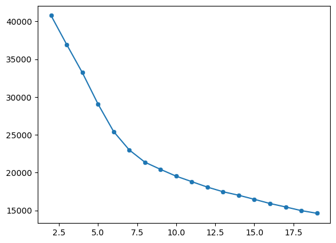

```python
num_clusters = np.arange(2,20) # list of potential number of clusters
wcss = [] # empty list to append model within-cluster sum of squares (wcss) to

# for loop iterating through different numbers of clusters
for i in num_clusters:
    model = KMeans(n_clusters=i, random_state = 123)
    model.fit(scaled_analysis_df)
    wcss.append(model.inertia_)

# plot number of clusters vs inertia to find elbow
sns.lineplot(x=num_clusters, y=wcss)
sns.scatterplot(x=num_clusters, y=wcss)
```

### D2: Code for Clustering Analysis

```python
# create final model
final_model=KMeans(n_clusters=8, random_state=123)
final_model.fit(scaled_analysis_df)

# insert cluster labels into original data set
churn_df['cluster_labels'] = final_model.labels_.tolist()
churn_df['cluster_labels'].value_counts()
```

```
cluster_labels
2    1562
7    1524
4    1523
6    1493
5    1127
1    1113
0     881
3     777
Name: count, dtype: int64
```

### E1: Quality of Clusters

To evaluate the quality of the clusters created by the model we will calculate the silhouette score for the model. The silhouette score compares how similar a point is to its own cluster versus other clusters (Sharma, 2024). It is a number between -1 and 1. A value of -1 indicates that the points are in the wrong cluster. A value of 1 indicates that the clusters are clearly separated from one another. A value of 0 implies that the clusters are close enough to eachother to not be significant.

The silhouette score for our model is 0.2. This indicates that the clusters are somewhat distinct from one another but still very close to eachother. This means that there is a posibility of overlap between clusters or some clusters may be very similar to one another.

```python
sil_score = silhouette_score(scaled_analysis_df, final_model.labels_)
sil_score
```

```
0.2031162832144122
```

### E2: Implications of Results

```python
# create dummy variables for looking more closely at cluster attributes
customer_df = pd.get_dummies(churn_df, columns=['churn', 'gender', 'contract', 'internetservice', 'phone',
                                               'onlinesecurity', 'onlinebackup', 'techsupport', 'streamingtv',
                                               'streamingmovies', 'paperlessbilling'])
```

```python
# look at the characteristics of the entire data set
customer_df.agg({
    'churn_Yes': 'mean',
    'age': 'median',
    'income': 'median',
    'monthlycharge': 'median',
    'tenure': 'median',
    'children': 'median',
    'gender_Male': 'mean',
    'contract_Month-to-month': 'mean'
}).round(2)
```

```
churn_Yes                      0.26
age                           53.00
income                     33170.60
monthlycharge                167.48
tenure                        35.43
children                       1.00
gender_Male                    0.47
contract_Month-to-month        0.55
dtype: float64
```

```python
# look at different characteristics of clusters
customer_df.groupby('cluster_labels').agg({
    'churn_Yes': 'mean',
    'age': 'median',
    'income': 'median',
    'monthlycharge': 'median',
    'tenure': 'median',
    'children': 'median',
    'gender_Male': 'mean',
    'contract_Month-to-month': 'mean'
}).round(2)
```

| cluster_labels | churn_Yes | age | income | monthlycharge | tenure | children | gender_Male | contract_Month-to-month |
| --- | --- | --- | --- | --- | --- | --- | --- | --- |
| 0 | 0.26 | 55.0 | 96442.41 | 162.50 | 39.23 | 1.0 | 0.43 | 0.56 |
| 1 | 0.83 | 52.0 | 31609.92 | 230.11 | 7.52 | 1.0 | 0.47 | 0.54 |
| 2 | 0.33 | 34.0 | 30909.92 | 152.46 | 7.85 | 1.0 | 0.48 | 0.54 |
| 3 | 0.23 | 49.0 | 34404.66 | 162.45 | 41.02 | 8.0 | 0.47 | 0.51 |
| 4 | 0.01 | 35.0 | 29567.14 | 149.99 | 61.29 | 1.0 | 0.47 | 0.56 |
| 5 | 0.18 | 54.0 | 30357.64 | 230.11 | 61.63 | 1.0 | 0.49 | 0.52 |
| 6 | 0.02 | 74.0 | 30057.73 | 152.46 | 61.83 | 1.0 | 0.47 | 0.54 |
| 7 | 0.36 | 72.0 | 28684.34 | 152.49 | 8.02 | 1.0 | 0.49 | 0.57 |

```python
customer_df.agg({
    'internetservice_DSL': 'mean',
    'internetservice_Fiber Optic': 'mean',
    'phone_Yes': 'mean',
    'onlinesecurity_Yes': 'mean',
    'techsupport_Yes': 'mean',
    'streamingtv_Yes': 'mean',
    'streamingmovies_Yes': 'mean',
    'paperlessbilling_Yes': 'mean'
}).round(2)
```

```
internetservice_DSL            0.35
internetservice_Fiber Optic    0.44
phone_Yes                      0.91
onlinesecurity_Yes             0.36
techsupport_Yes                0.38
streamingtv_Yes                0.49
streamingmovies_Yes            0.49
paperlessbilling_Yes           0.59
dtype: float64
```

```python
# look at different characteristics of clusters
customer_df.groupby('cluster_labels').agg({
    'internetservice_DSL': 'mean',
    'internetservice_Fiber Optic': 'mean',
    'phone_Yes': 'mean',
    'onlinesecurity_Yes': 'mean',
    'techsupport_Yes': 'mean',
    'streamingtv_Yes': 'mean',
    'streamingmovies_Yes': 'mean',
    'paperlessbilling_Yes': 'mean'
}).round(2)
```

| cluster_labels | internetservice_DSL | internetservice_Fiber Optic | phone_Yes | onlinesecurity_Yes | techsupport_Yes | streamingtv_Yes | streamingmovies_Yes | paperlessbilling_Yes |
| --- | --- | --- | --- | --- | --- | --- | --- | --- |
| 0 | 0.38 | 0.41 | 0.90 | 0.33 | 0.40 | 0.45 | 0.47 | 0.58 |
| 1 | 0.30 | 0.58 | 0.89 | 0.40 | 0.42 | 0.86 | 0.91 | 0.58 |
| 2 | 0.35 | 0.40 | 0.91 | 0.35 | 0.32 | 0.36 | 0.34 | 0.59 |
| 3 | 0.36 | 0.42 | 0.90 | 0.38 | 0.38 | 0.48 | 0.46 | 0.61 |
| 4 | 0.37 | 0.40 | 0.90 | 0.35 | 0.34 | 0.37 | 0.31 | 0.58 |
| 5 | 0.31 | 0.57 | 0.90 | 0.39 | 0.43 | 0.87 | 0.92 | 0.59 |
| 6 | 0.35 | 0.41 | 0.92 | 0.34 | 0.37 | 0.36 | 0.35 | 0.60 |
| 7 | 0.36 | 0.39 | 0.91 | 0.35 | 0.38 | 0.37 | 0.35 | 0.59 |

### E3: Limitations of Analysis

One important limitation of using K-means clustering is that the clusters can be very dependent on the initial positions of the cluster centers. This may result in the algorithm not finding the most accurate clusters or could result in the same code producing different clusters on subsuquent runs (Patel, 2023). For this analysis, the random_state parameter was used to ensure that the same result would be produced every time the code is run.

### E4: Recommendations

In this analysis we produced several clusters of customers that have the potential to provide information that could be used for marketing or other business decisions. Our recommendation is that these clusters be further investigated to fully understand what may cause a customer to become apart of one cluster versus the other.

### F: Panopto Video

https://wgu.hosted.panopto.com/Panopto/Pages/Viewer.aspx?id=574f77db-a698-49f7-8a25-b16a00e8dc4f

### G: Coding Sources

No coding sources were used for this project.

### H: Text Sources

Patel, K. (2023, July 4). *Understanding the Limitations of K-Means Clustering*. Medium. https://medium.com/@kadambaripatel79/understanding-the-limitations-of-k-means-clustering-1fb5335f7859

Sharma, P. (2024, May 2). *The Ultimate Guide to K-Means Clustering: Definition, Methods, and Applications*. Analytics Vidhya. https://www.analyticsvidhya.com/blog/2019/08/comprehensive-guide-k-means-clustering/